# Q & K Box 15.1

### Do biplots with scaling=1 (plot distances match euclidean dists - angles between variables irrelevant) and scaling=2

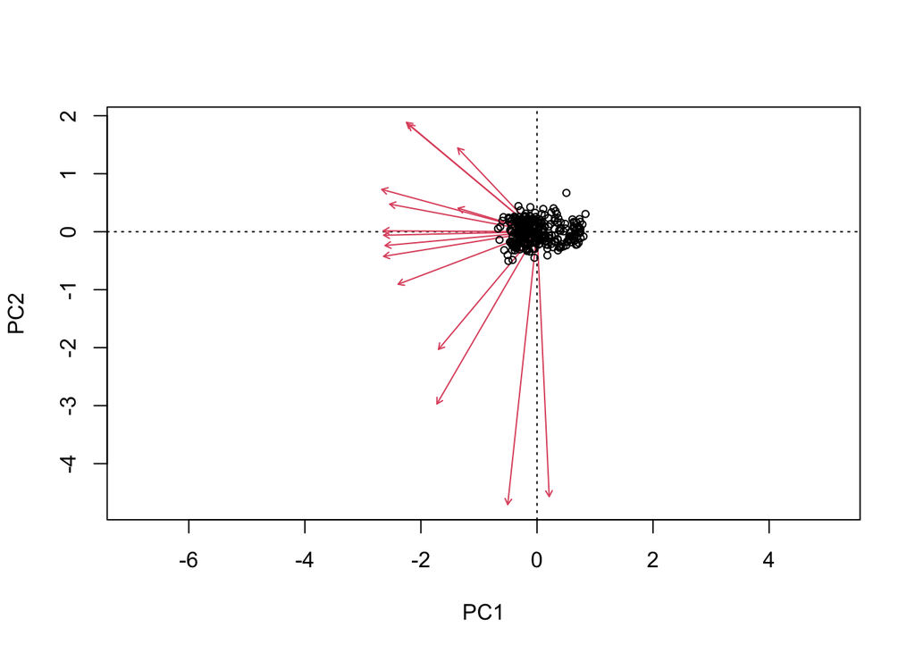

```r
biplot(wu1.rda, scaling=1)
```

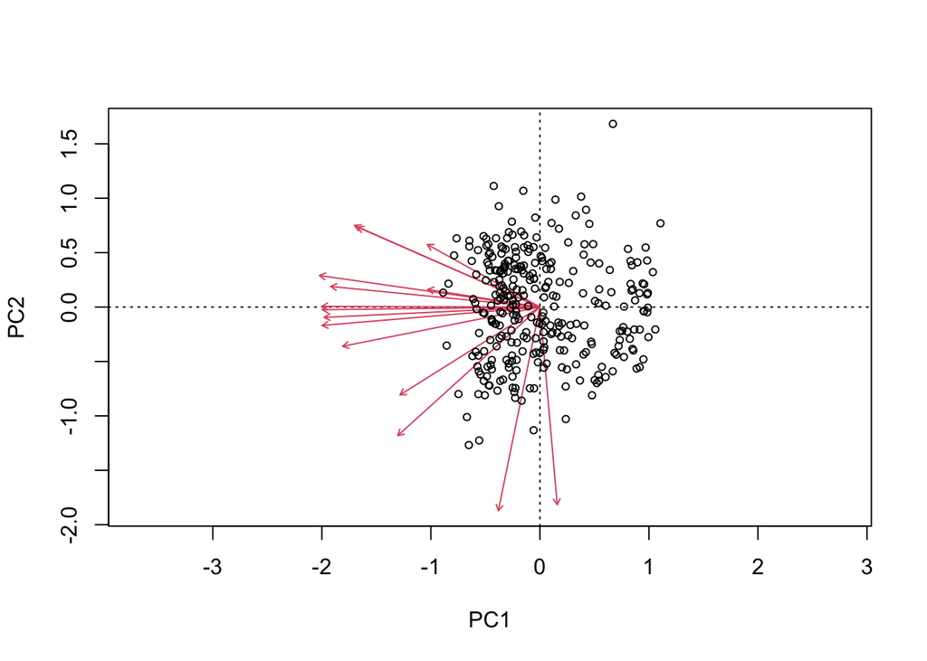

```r
# now with scaling=2 - this is more useful
biplot(wu1.rda, scaling=2)
```

[figure not shown]

```r
# try with ordiplot (default scale=2)
ordiplot(wu1.rda, choices=c(1,2), display='sites', type='none')
```

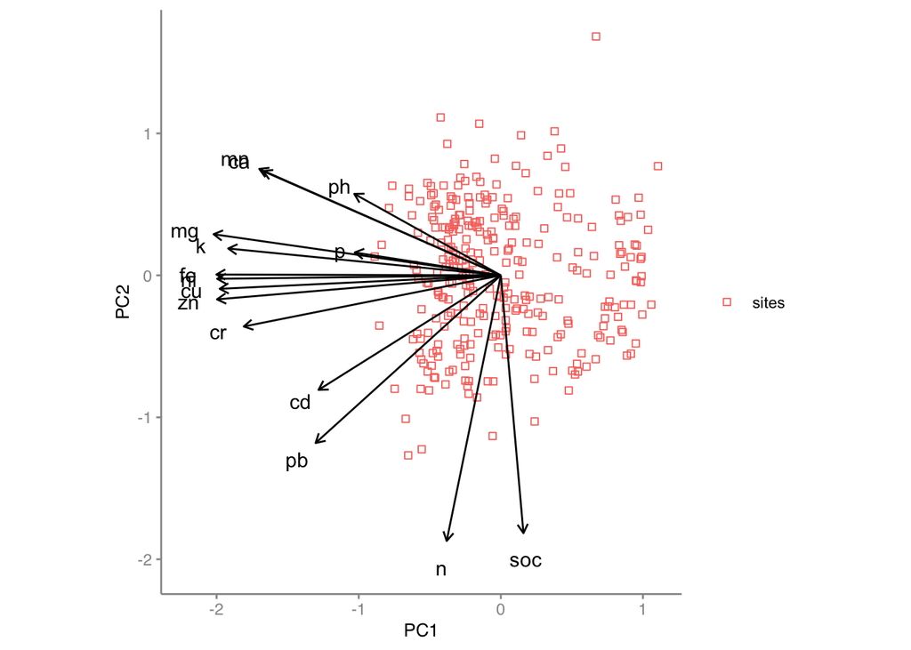

```r
#points (wu1.rda, col = wu$group, pch = wu$group)
autoplot(wu1.rda, shape = wu$group,
         label = TRUE, label.size = 3,  loadings = TRUE,
         loadings.label = TRUE, loadings.label.size = 3, scale= 0
         ) +
#geom_point(data = wu1.rda,aes(RDA1,RDA2,colour = landuse),size=2,alpha=0.5)
scale_shape_manual(values=c(0,1,2))+
  theme_qk()+
  theme(
    legend.title = element_blank()
  )
```

Try varimax rotation

```r
principal(wu.cor, n.obs=300, nfactors=3, rotate="varimax")
```

```
## Principal Components Analysis
## Call: principal(r = wu.cor, nfactors = 3, rotate = "varimax", n.obs = 300)
## Standardized loadings (pattern matrix) based upon correlation matrix
##       RC1   RC3   RC2   h2    u2 com
## ca   0.50  0.78 -0.16 0.88 0.115 1.8
## cd   0.40  0.46  0.51 0.63 0.370 2.9
## cr   0.89  0.13  0.17 0.83 0.172 1.1
## cu   0.89  0.31  0.09 0.90 0.102 1.3
## fe   0.94  0.26  0.02 0.94 0.057 1.2
## mg   0.85  0.47 -0.05 0.93 0.066 1.6
## mn   0.73  0.40 -0.29 0.78 0.219 1.9
## ni   0.90  0.31  0.05 0.92 0.084 1.2
## pb   0.72 -0.13  0.50 0.79 0.213 1.9
## zn   0.81  0.46  0.17 0.90 0.097 1.7
## ph   0.11  0.84 -0.04 0.73 0.273 1.0
## soc -0.14 -0.06  0.89 0.81 0.186 1.1
## n    0.13 -0.03  0.91 0.85 0.155 1.0
## p    0.30  0.47  0.04 0.31 0.690 1.7
## k    0.81  0.43 -0.01 0.83 0.167 1.5
##
##                        RC1  RC3  RC2
## SS loadings           6.91 2.81 2.32
## Proportion Var        0.46 0.19 0.15
## Cumulative Var        0.46 0.65 0.80
## Proportion Explained  0.57 0.23 0.19
## Cumulative Proportion 0.57 0.81 1.00
##
## Mean item complexity =  1.5
## Test of the hypothesis that 3 components are sufficient.
##
## The root mean square of the residuals (RMSR) is  0.05
##  with the empirical chi square  141  with prob <  6.2e-08
##
## Fit based upon off diagonal values = 0.99
```

### Do PCA on covariance matrix

```r
options(digits=10)
wu2.rda <- rda(wu[,c('ca','cd','cr','cu','fe','mg','mn','ni','pb','zn','ph','soc','n','p','k')],scale=FALSE)
summary(wu2.rda)
```

```
##
## Call:
## rda(X = wu[, c("ca", "cd", "cr", "cu", "fe", "mg", "mn", "ni",      "pb", "zn", "ph", "soc", "n", "p", "k")], scale = FALSE)
##
## Partitioning of variance:
##                Inertia Proportion
## Total         163243.5          1
## Unconstrained 163243.5          1
##
## Eigenvalues, and their contribution to the variance
##
## Importance of components:
##                                PC1          PC2          PC3          PC4
## Eigenvalue            7.571096e+04 6.145057e+04 2.589640e+04 1.392029e+02
## Proportion Explained  4.637916e-01 3.764350e-01 1.586366e-01 8.527314e-04
## Cumulative Proportion 4.637916e-01 8.402266e-01 9.988632e-01 9.997159e-01
##                                PC5          PC6          PC7          PC8
## Eigenvalue            3.397364e+01 5.4839052446 4.100869e+00 2.234922e+00
## Proportion Explained  2.081163e-04 0.0000335934 2.512118e-05 1.369073e-05
## Cumulative Proportion 9.999240e-01 0.9999576051 9.999827e-01 9.999964e-01
##                                PC9         PC10         PC11         PC12
## Eigenvalue            4.691284e-01 4.395120e-02 3.221747e-02 1.674771e-02
## Proportion Explained  2.873795e-06 2.692370e-07 1.973584e-07 1.025934e-07
## Cumulative Proportion 9.999993e-01 9.999996e-01 9.999998e-01 9.999999e-01
##                               PC13         PC14         PC15
## Eigenvalue            1.450067e-02 6.185779e-03 2.163316e-03
## Proportion Explained  8.882845e-08 3.789295e-08 1.325208e-08
## Cumulative Proportion 9.999999e-01 1.000000e+00 1.000000e+00
```

```r
scores(wu2.rda, choices=c(1:2), display='species', scaling = 0)
```

```
##                  PC1              PC2
## ca  -6.780347384e-04  0.0000393311470
## cd  -7.924296995e-05 -0.0001208304870
## cr  -1.505061899e-02 -0.0100552056778
## cu  -1.301256365e-02 -0.0047167216016
## fe  -1.336204061e-03 -0.0003822526200
## mg  -9.320674429e-04 -0.0001445224866
## mn  -5.057055320e-01  0.1516436533552
## ni  -1.358915845e-02 -0.0047466690877
## pb  -1.836676627e-03 -0.0044869147439
## zn  -4.460512507e-02 -0.0210024334415
## ph  -7.883329614e-04  0.0001542414662
## soc  1.895087365e-04 -0.0005959401288
## n    1.458232008e-01 -0.9551859159818
## p   -8.487752702e-01 -0.2530145375865
## k   -8.766107829e-04 -0.0001728739345
## attr(,"const")
## [1] 83.58469892
```

```r
wu2.cov <- cov(wu[,c('ca','cd','cr','cu','fe','mg','mn','ni','pb','zn','ph','soc','n','p','k')])
wu2.vec <- eigen(wu2.cov)
print(wu2.vec)
```

```
## eigen() decomposition
## $values
##  [1] 7.571096416e+04 6.145057283e+04 2.589639838e+04 1.392028752e+02
##  [5] 3.397363594e+01 5.483905245e+00 4.100869117e+00 2.234922443e+00
##  [9] 4.691284042e-01 4.395119845e-02 3.221747328e-02 1.674770957e-02
## [13] 1.450066788e-02 6.185779103e-03 2.163315794e-03
##
## $vectors
##                   [,1]             [,2]             [,3]             [,4]
##  [1,] -6.780347384e-04  0.0000393311470 -6.922323577e-04 -0.0055201384769
##  [2,] -7.924296995e-05 -0.0001208304870 -1.462417343e-04 -0.0012807979215
##  [3,] -1.505061899e-02 -0.0100552056778 -3.602119960e-02 -0.5489081279879
##  [4,] -1.301256365e-02 -0.0047167216016 -1.793167321e-02 -0.2420179714088
##  [5,] -1.336204061e-03 -0.0003822526200 -2.549790169e-03 -0.0251984533206
##  [6,] -9.320674429e-04 -0.0001445224866 -1.436406292e-03 -0.0150585984553
```

[output cut: 57 more lines]

```r
# get true loadings as correlations
wu2.load <- eigen.loadings(wu2.vec)
print(wu2.load)
```

```
##                   [,1]             [,2]             [,3]            [,4]
##  [1,]   -0.18656549874  9.749886941e-03   -0.11139650872 -0.065128949812
##  [2,]   -0.02180419877 -2.995294256e-02   -0.02353374333 -0.015111400538
##  [3,]   -4.14127194335 -2.492607666e+00   -5.79666037095 -6.476252374556
##  [4,]   -3.58048826931 -1.169238780e+00   -2.88562903548 -2.855431322846
##  [5,]   -0.36766490415 -9.475746608e-02   -0.41032136044 -0.297302107278
##  [6,]   -0.25646418614 -3.582600589e-02   -0.23115164191 -0.177667771765
##  [7,] -139.14803985809  3.759128803e+01 -136.03205900011  0.958795082296
##  [8,]   -3.73914193411 -1.176662530e+00   -4.52863670922 -4.076074114246
##  [9,]   -0.50537306064 -1.112271439e+00   -0.93158266871 -0.753439356435
## [10,]  -12.27337912799 -5.206340703e+00   -8.24408591228 -8.404728559842
## [11,]   -0.21691474462  3.823526572e-02   -0.23055076528 -0.155684374694
## [12,]    0.05214451404 -1.477289457e-01    0.00920806957  0.005814642296
## [13,]   40.12416568566 -2.367831959e+02  -41.08530125198  0.399372879114
## [14,] -233.54582388473 -6.272034567e+01   74.64632596154  0.165594895050
```

[output cut: 49 more lines]

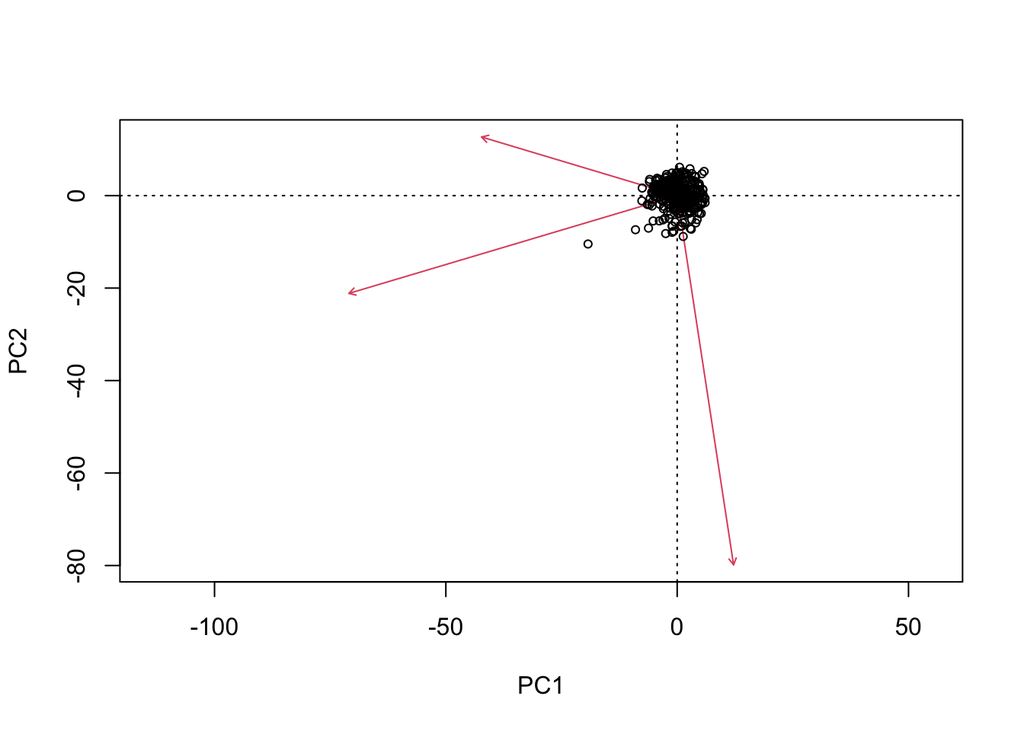

```r
biplot(wu2.rda, scaling=1)
```

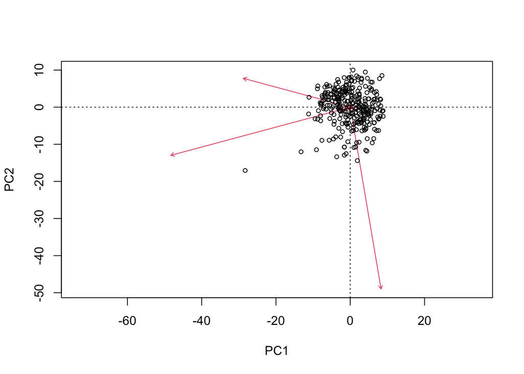

```r
biplot(wu2.rda, scaling=2)
```

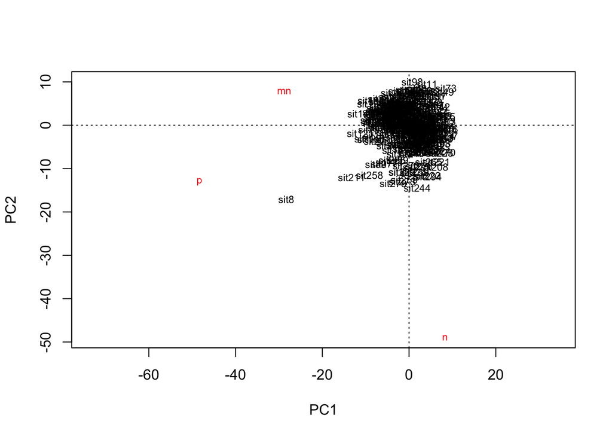

```r
ordiplot(wu2.rda, choices=c(1,2), type='text')
```

### Do pca on correlation & covariance matrices with princomp

Correlation matrix

```r
wu1.pca <- princomp(~ca+cd+cr+cu+fe+mg+mn+ni+pb+zn+ni+ph+soc+n+p+k, cor=T, data=wu)
summary(wu1.pca)
```

```
## Importance of components:
##                              Comp.1       Comp.2        Comp.3        Comp.4
## Standard deviation     2.9272302613 1.5400496837 1.04570938871 0.95162944936
## Proportion of Variance 0.5712451335 0.1581168685 0.07290054171 0.06037324059
## Cumulative Proportion  0.5712451335 0.7293620020 0.80226254376 0.86263578435
##                               Comp.5        Comp.6        Comp.7        Comp.8
## Standard deviation     0.70441478608 0.56339607069 0.55034751910 0.49710666852
## Proportion of Variance 0.03308001272 0.02116100883 0.02019215945 0.01647433599
## Cumulative Proportion  0.89571579707 0.91687680590 0.93706896536 0.95354330135
##                               Comp.9       Comp.10        Comp.11
## Standard deviation     0.46271997591 0.39706231423 0.331349891270
## Proportion of Variance 0.01427398507 0.01051056543 0.007319516696
## Cumulative Proportion  0.96781728642 0.97832785185 0.985647368544
##                               Comp.12        Comp.13       Comp.14
## Standard deviation     0.274024190279 0.241732174358 0.22294524608
## Proportion of Variance 0.005005950457 0.003895629608 0.00331363885
## Cumulative Proportion  0.990653319001 0.994548948609 0.99786258746
##                               Comp.15
## Standard deviation     0.179056382494
## Proportion of Variance 0.002137412541
## Cumulative Proportion  1.000000000000
```

```r
loadings(wu1.pca)
```

```
##
## Loadings:
##     Comp.1 Comp.2 Comp.3 Comp.4 Comp.5 Comp.6 Comp.7 Comp.8 Comp.9 Comp.10
## ca   0.270  0.226  0.354         0.121         0.175  0.247  0.204  0.533
## cd   0.207 -0.248  0.325        -0.847        -0.143 -0.135
## cr   0.292 -0.111 -0.246  0.181        -0.119 -0.353 -0.452  0.273 -0.151
## cu   0.320        -0.132                             -0.150  0.166  0.267
## fe   0.324        -0.205                                     0.164
## mg   0.327                              0.263               -0.136
## mn   0.275  0.230               -0.185  0.185  0.653         0.259 -0.514
## ni   0.323        -0.146  0.170               -0.199
## pb   0.211 -0.363 -0.293               -0.668  0.347  0.278 -0.195  0.117
## zn   0.323               -0.158         0.128                       0.224
## ph   0.167  0.176  0.616  0.443  0.172 -0.445                      -0.253
## soc        -0.558  0.252         0.316  0.211  0.395 -0.513 -0.178  0.111
## n          -0.575  0.161         0.156  0.222 -0.174  0.553  0.340 -0.312
## p    0.166         0.249 -0.836  0.182 -0.247 -0.171               -0.213
## k    0.310                              0.222         0.149 -0.746 -0.234
##     Comp.11 Comp.12 Comp.13 Comp.14 Comp.15
## ca   0.429   0.200   0.221   0.140   0.136
## cd
## cr   0.343           0.463          -0.170
## cu  -0.671   0.521                   0.128
## fe   0.107  -0.295  -0.273  -0.690   0.391
## mg           0.110  -0.346  -0.170  -0.777
## mn                           0.127
## ni   0.138          -0.568   0.606   0.286
## pb   0.110                          -0.142
## zn  -0.355  -0.731   0.253   0.249  -0.105
## ph  -0.210                  -0.110
## soc
## n
## p    0.128          -0.112
## k            0.153   0.334           0.246
##
##                Comp.1 Comp.2 Comp.3 Comp.4 Comp.5 Comp.6 Comp.7 Comp.8 Comp.9
## SS loadings     1.000  1.000  1.000  1.000  1.000  1.000  1.000  1.000  1.000
## Proportion Var  0.067  0.067  0.067  0.067  0.067  0.067  0.067  0.067  0.067
## Cumulative Var  0.067  0.133  0.200  0.267  0.333  0.400  0.467  0.533  0.600
##                Comp.10 Comp.11 Comp.12 Comp.13 Comp.14 Comp.15
## SS loadings      1.000   1.000   1.000   1.000   1.000   1.000
## Proportion Var   0.067   0.067   0.067   0.067   0.067   0.067
## Cumulative Var   0.667   0.733   0.800   0.867   0.933   1.000
```

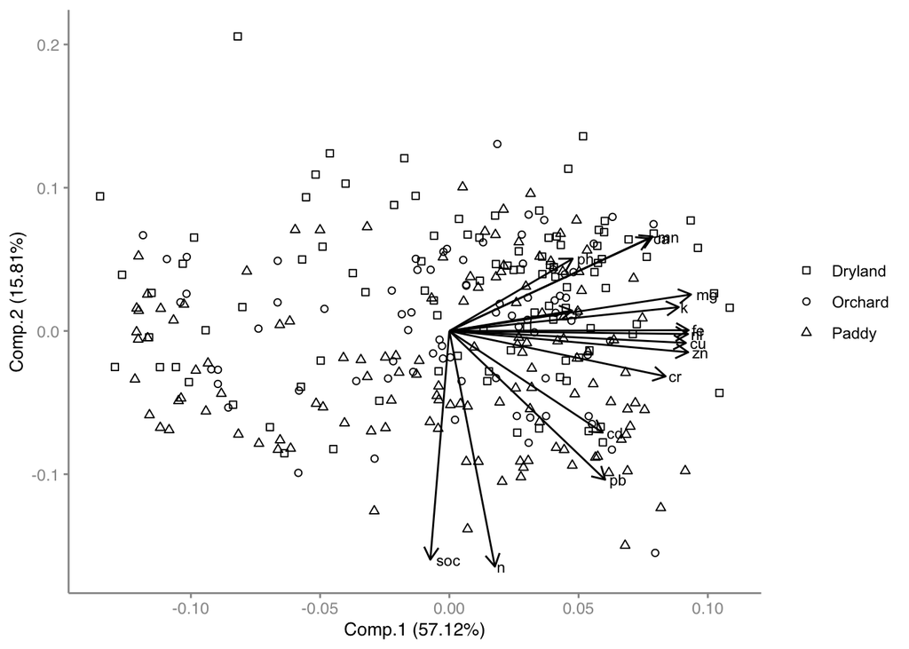

```r
autoplot(wu1.pca, data=wu, shape = "landuse", scale=1,
         loadings = TRUE, loadings.colour = 'black',
         loadings.label = TRUE, loadings.label.size = 3,
         loadings.label.colour="black", loadings.label.hjust=-0.25
         )+
scale_shape_manual(values=c(0,1,2))+
  theme_qk()+
  theme(
    legend.title = element_blank()
  )
```

PCA on covariance matrix with princomp

```r
wu2.pca <- princomp(~ca+cd+cr+cu+fe+mg+mn+ni+pb+zn+ni+ph+soc+n+p+k, cor=F, data=wu)
summary(wu2.pca)
```

```
## Importance of components:
##                                Comp.1         Comp.2        Comp.3
## Standard deviation     274.6972775170 247.4787619002 160.655149471
## Proportion of Variance   0.4637915538   0.3764349982   0.158636612
## Cumulative Proportion    0.4637915538   0.8402265521   0.998863164
##                                 Comp.4          Comp.5          Comp.6
## Standard deviation     1.177874635e+01 5.8189681630445 2.337867738e+00
## Proportion of Variance 8.527314177e-04 0.0002081162956 3.359340305e-05
## Cumulative Proportion  9.997158954e-01 0.9999240117365 9.999576051e-01
##                                 Comp.7          Comp.8          Comp.9
## Standard deviation     2.021682357e+00 1.492472010e+00 6.837869865e-01
## Proportion of Variance 2.512117605e-05 1.369072715e-05 2.873795017e-06
## Cumulative Proportion  9.999827263e-01 9.999964170e-01 9.999992908e-01
##                                Comp.10         Comp.11         Comp.12
## Standard deviation     2.092957106e-01 1.791928617e-01 1.291970738e-01
## Proportion of Variance 2.692370233e-07 1.973583636e-07 1.025934134e-07
## Cumulative Proportion  9.999995601e-01 9.999997574e-01 9.999998600e-01
##                                Comp.13         Comp.14         Comp.15
## Standard deviation     1.202178536e-01 7.851853182e-02 4.643387504e-02
## Proportion of Variance 8.882844597e-08 3.789295426e-08 1.325207794e-08
## Cumulative Proportion  9.999999489e-01 9.999999867e-01 1.000000000e+00
```

```r
loadings(wu2.pca)
```

```
##
## Loadings:
##     Comp.1 Comp.2 Comp.3 Comp.4 Comp.5 Comp.6 Comp.7 Comp.8 Comp.9 Comp.10
## ca                                                           0.131  0.236
## cd
## cr                        0.549 -0.710 -0.428
## cu                        0.242         0.271 -0.881  0.292
## fe                                                                  0.648
## mg                                                                  0.423
## mn   0.506  0.152  0.845
## ni                        0.345 -0.199  0.839  0.351
## pb                                            -0.276 -0.940  0.174
## zn                        0.712  0.670 -0.176
## ph                                                    0.152  0.970
## soc
## n   -0.146 -0.955  0.255
## p    0.849 -0.253 -0.464
## k                                                                   0.574
##     Comp.11 Comp.12 Comp.13 Comp.14 Comp.15
## ca   0.197   0.170   0.835   0.401
## cd                                  -0.995
## cr
## cu
## fe   0.621  -0.237  -0.333   0.125
## mg                   0.300  -0.848
## mn
## ni
## pb
## zn
## ph                  -0.139
## soc -0.137  -0.955   0.242
## n
## p
## k   -0.738          -0.149   0.318
##
##                Comp.1 Comp.2 Comp.3 Comp.4 Comp.5 Comp.6 Comp.7 Comp.8 Comp.9
## SS loadings     1.000  1.000  1.000  1.000  1.000  1.000  1.000  1.000  1.000
## Proportion Var  0.067  0.067  0.067  0.067  0.067  0.067  0.067  0.067  0.067
## Cumulative Var  0.067  0.133  0.200  0.267  0.333  0.400  0.467  0.533  0.600
##                Comp.10 Comp.11 Comp.12 Comp.13 Comp.14 Comp.15
## SS loadings      1.000   1.000   1.000   1.000   1.000   1.000
## Proportion Var   0.067   0.067   0.067   0.067   0.067   0.067
## Cumulative Var   0.667   0.733   0.800   0.867   0.933   1.000
```

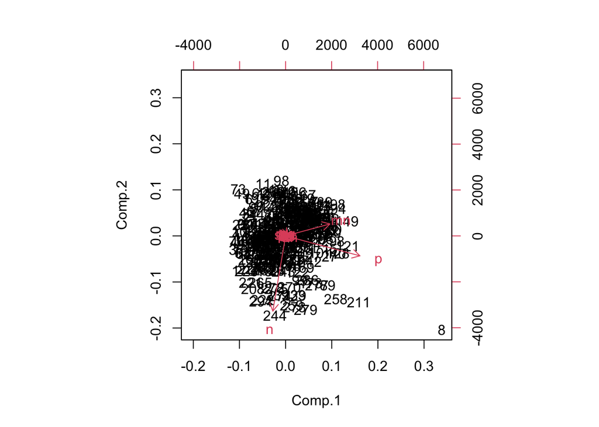

```r
# do biplot
biplot(wu2.pca)
```

### Repeat plot with ggplot2 in progress

do biplots with scaling=1 (plot distances match euclidean dists - angles between variables irrelevant) and scaling=2

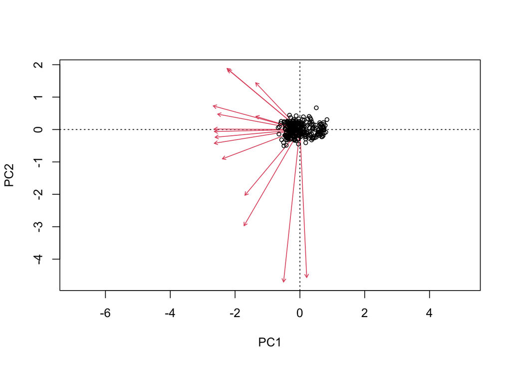

```r
biplot(wu1.rda, scaling=1)
```

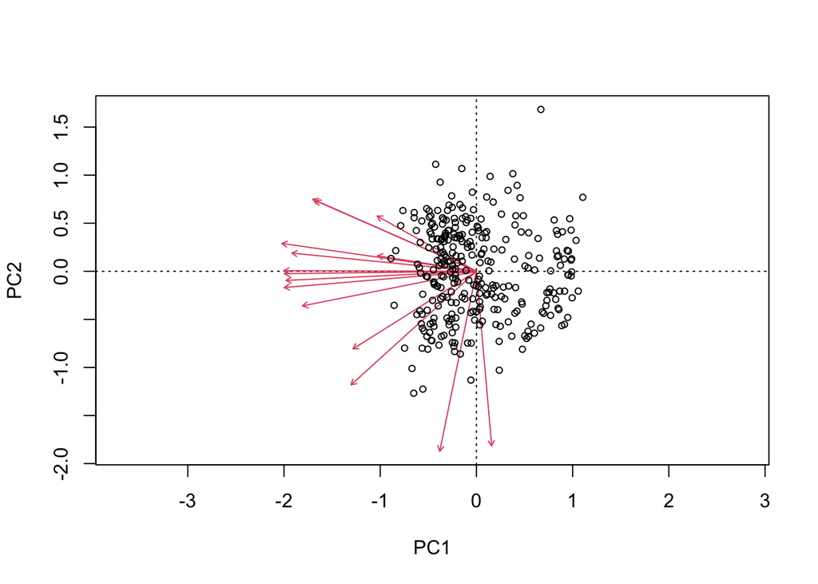

```r
biplot(wu1.rda, scaling=2)
```

```r
p<-autoplot(wu1.rda, scale=1)
#ordiplot(wu1.rda, choices=c(1,2), display='sites', type='none')
#points (wu1.rda, col = wu$group, pch = wu$group )
```

do pca on correlation matrix with princomp

```r
f15_3a<-autoplot(wu1.pca, data=wu, shape = "landuse", scale=1,colour=sc,
         loadings = TRUE, loadings.colour = 'black',
         loadings.label = TRUE, loadings.label.size = 3,
         loadings.label.colour="black", loadings.label.repel=TRUE
         )+
scale_shape_manual(values=c(0,1,2))+
  theme_qk()+
  theme(
    legend.title = element_blank()
  )
```

## Figures

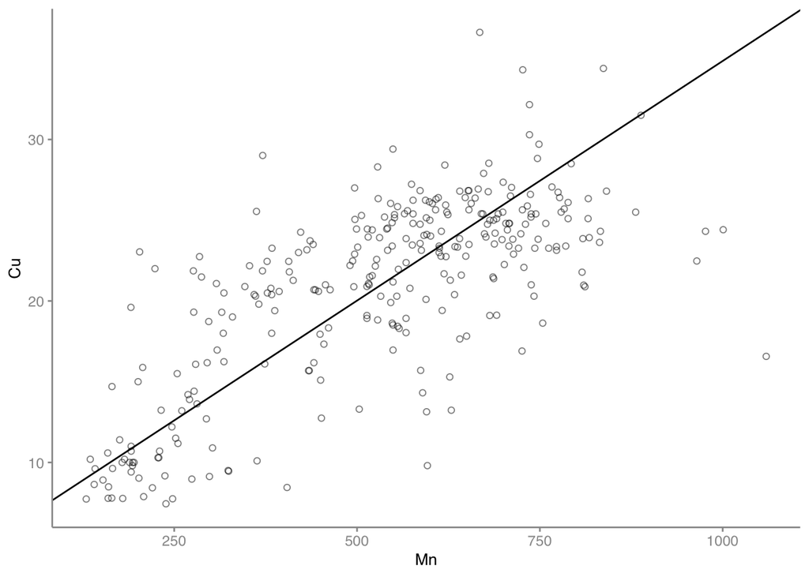

```r
f15_1<-ggplot(wu)+
  geom_point(aes(x=mn,y=cu), alpha=0.5,shape=1)+
  geom_abline(intercept=wu1.rma$regression.results[3,2],
              slope=wu1.rma$regression.results[3,3], colour="black")+
  labs(x="Mn", y="Cu")+
  theme_qk()
f15_1
```

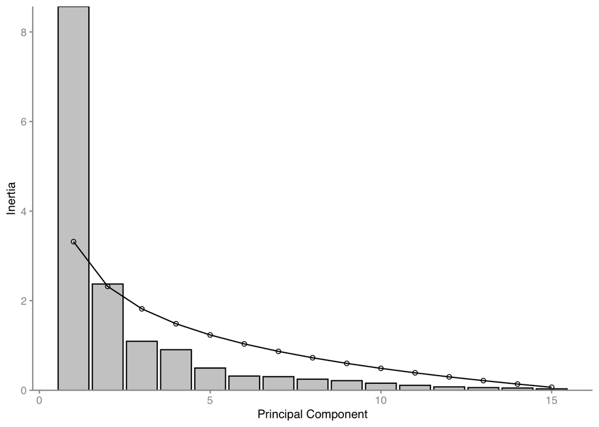

```r
#Ugly little workaround to get single file with eigenvalues and broken stick into simple file
f1<-as.data.frame(bstick(wu1.rda))
a2<-as.data.frame(wu1.rda$CA$eig)
a2<-cbind(a2,f1)
a2$PC<-row.names(a2)
names(a2)[names(a2) == 'wu1.rda$CA$eig'] <- 'eig'
names(a2)[names(a2) == 'bstick(wu1.rda)'] <- 'bs'
a2$PC <- factor(a2$PC, levels = a2$PC)
a2$ID <- seq_along(a2[,1])
f15_2<-ggplot(a2)+
  geom_bar(aes(x=ID,y=eig),stat="identity", color=lc, fill=lf)+
  scale_y_continuous(expand = c(0,0))+
  geom_line(aes(x=ID,y=bs))+
  geom_point(aes(x=ID,y=bs), shape=1)+
  labs(y="Inertia",x="Principal Component")+
  theme_qk()
f15_2
```

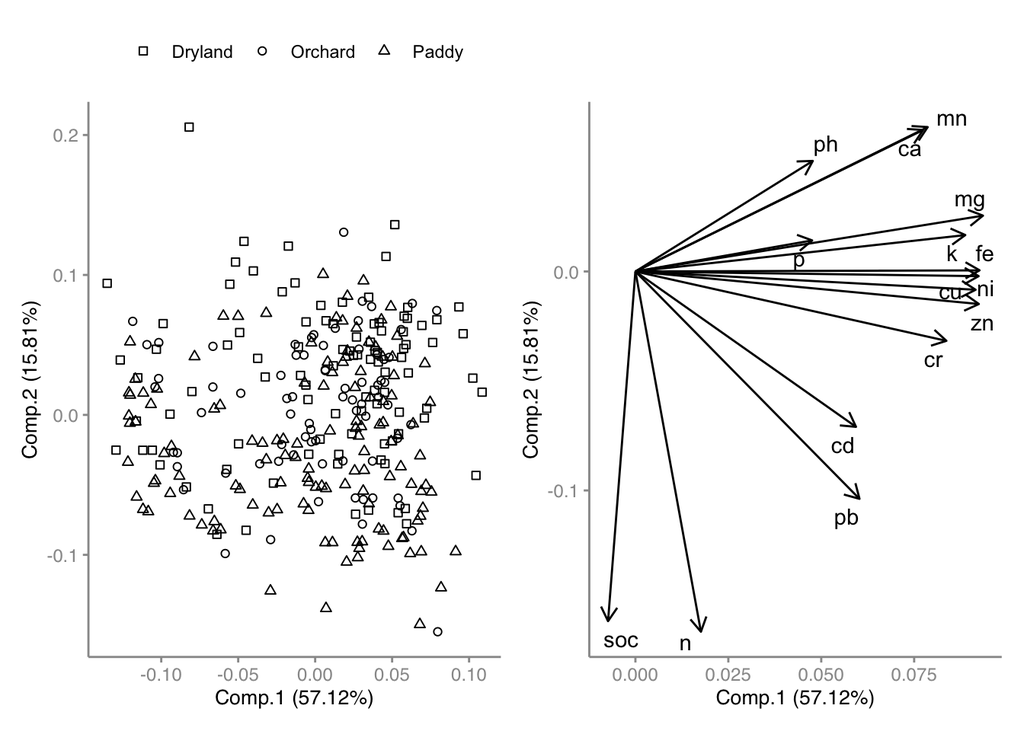

```r
p1<-autoplot(wu1.pca, data=wu, shape='landuse')
p1<-p1+scale_shape_manual(values=c(0,1,2))+
  theme_qk()+
  theme(
    legend.position = "top",
    legend.title=element_blank()
  )
p2<-autoplot(wu1.pca, shape=FALSE,label=FALSE,
         loadings=TRUE, loadings.label=TRUE,
         loadings.label.colour="black",
         loadings.colour="black",
         loadings.label.repel=TRUE
)+
  theme_qk()
f15_3<-p1+p2
f15_3
```